# QTM 151 - Quiz 1

## Try to submit as an HTML file

Print your name below

```python
# Write your own code

print("Samantha Lim")
```

```
Samantha Lim
```

This quiz is open book

- You can use the lecture notes
- You will get partial credit for attempting the questions
- To get full credit, the code should run as intended
- You should NOT communicate with other students

Print the following message:

"I will abide by Emory's code of conduct"

```python
## Write your own code

print("I will abide by Emory's code of conduct.")
```

```
I will abide by Emory's code of conduct.
```

Import the libraries "numpy", "matplotlib.pytplot", and "pandas"

```python
# Write your own code
import numpy as np
import matplotlib.pyplot as plt
import pandas as pd
```

## Part I: Visualizing random variables

(a) Create two random variables ...

- Call them "vec_x" and "vec_z"
- Generate "vec_x" from a chi-square with (df = 5, size = 1000)
- Generate "vec_z" from a chi-square distribution with (df = 1, size = 1000)
- Plot a histogram of each variable
  - Label the axes and title
  - Each graph should have a different title

To get full points, plot the histograms on a grid (See Lecture 6)

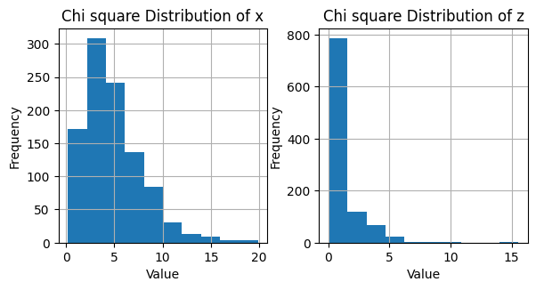

```python
# Write your own code
vec_x = np.random.chisquare(df=5, size=1000)
vec_z = np.random.chisquare(df=1, size=1000)

fig, list_subfig = plt.subplots(1, 2,figsize = (6,3))

plt.tight_layout()

list_subfig[0].hist(x = vec_x)
list_subfig[0].set_title("Chi square Distribution of x")
list_subfig[0].set_xlabel("Value")
list_subfig[0].set_ylabel("Frequency")
list_subfig[0].grid()

list_subfig[1].hist(x = vec_z)
list_subfig[1].set_title("Chi square Distribution of z")
list_subfig[1].set_xlabel("Value")
list_subfig[1].set_ylabel("Frequency")
list_subfig[1].grid()
```

(b) Create a new variable "vec_y" by the formula

$ y = sin(x) + 2x + 5$

- Use element-by-element vector operations (no loops)
- Produce a scatter plot of "vec_y" against "vec_x"
- Label the axes and the title
- Change the color to "red", "green" or "purple" (you choose)

Hint: You can use the numpy "sin()" function with vector arrays

```
[5.0, 7.841470984807897, 9.909297426825681, 12.243197504692072, 14.041075725336862, 16.720584501801074, 19.656986598718788, 21.989358246623382, 23.412118485241756, 24.45597888911063]
```

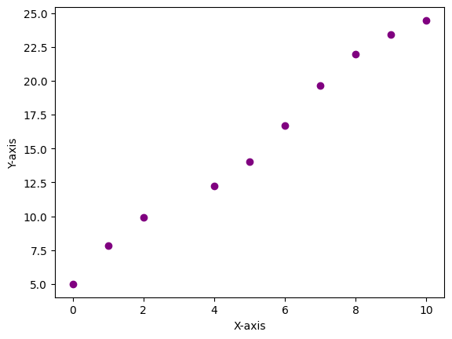

```python
# Write your own code
n = 50
vec_x = [0,1,2,4,5,6,7,8,9,10]
vec_y = []

index = 0
for x in vec_x:
    y = np.sin(vec_x[index]) + 2*vec_x[index] + 5
    vec_y.append(y)
    index = index + 1

print(vec_y)
plt.scatter(vec_x, vec_y, color = 'purple')
plt.xlabel("X-axis")
plt.ylabel("Y-axis")
```

## Part II: Operations over multiple datasets

(c) Create two lists with ...

- The names of the datasets
- The years of the datasets (type manually based on the dataset names)

To answer this question, you need to browse the Quiz folder

You will find three datasets on worldwide CO2 emissions

```python
# Write your own code
list_names = ["data/wdi_co2_2005.csv", "data/wdi_co2_2010.csv", "data/wdi_co2_2015.csv"]
list_years = [2005,2010,2015]
```

(d) Create a loop that ...

- Goes over the list of years
- If the year $\ge$ 2012, print the message

$\qquad$ "This dataset contains information on or after 2012.

- If the year $<$ 2012, print the message

$\qquad$ "This dataset contains information before 2012"

```python
# Write your own code
for years in list_years:
    if years >= 2012:
        print("This dataset contains information on or after 2012.")
    if years < 2012:
        print("This dataset contains information before 2012.")
```

```
This dataset contains information before 2012.
This dataset contains information before 2012.
This dataset contains information on or after 2012.
```

(e) Your goal is to convert all the ".csv" data files to ".xlsx" (Excel) files

- Create a list with the ".csv" dataset names (including their relative subfolder "data_quiz/)
- Create a new list called "list_newnames", with each element ending in ".xlsx" (including the subfolder "data_excel/")
- Start an index

$\qquad$ index = 0

- Initiate a for loop over the list of dataset names. Inside the loop:
  - Read the ".csv" dataset and store it in an object called "dataset"
  - Create a variable called "filename" from the "list_newnames", extracting the element "index"
  - Store "dataset" as an excel file with name "filename".

  $\qquad$ index = index + 1

Note: Check that you did it correctly by trying to open your new excel files outside "VSCode"

```python
# Write your own code

list_csvnames = ["data_quiz/wdi_co2_2005.csv", "data_quiz/wdi_co2_2010.csv", "data_quiz/wdi_co2_2015.csv"]
list_newnames = ["data_excel/wdi_co2_2005.xlsx", "data_excel/wdi_co2_2010.xlsx", "data_excel/wdi_co2_2015.xlsx"]

index = 0

for csvnames in list_csvnames:
    dataset = pd.read_csv(csvnames)
    filename = list_newnames.index
    dataset.to_excel("data_excel/filename_stored.xlsx")
index = index + 1
```

(f) Your goal is to open each dataset, create a new variable, then plot

- Create a list with the ".csv" dataset names (including their relative subfolder "data_quiz/)
- Start an index

$\qquad$ index = 0

- Initiate a for loop over the list of dataset names. Inside the loop:
  - Read the dataset and store it in an object called "dataset"
  - Create two new variables as

  $\qquad$ co2_gasfuel_kt = dataset["co2_gasfuel_kt"]  
  $\qquad$ co2_liquidfuel_kt = dataset["co2_liquidfuel_kt"]
  - Calculate the total CO2 emissions driven by gas and liquid fuel by adding the two previous variables.
  - Plot a histogram and label the axes
  - Use plt.show() to display the plot
  - Write

  $\qquad$ index = index + 1

This should produce a histogram for each dataset

```python
# Write your own code
list_csvnames = ["data_quiz/wdi_co2_2005.csv", "data_quiz/wdi_co2_2010.csv", "data_quiz/wdi_co2_2015.csv"]

index = 0
for csvnames in list_csvnames:
    dataset = pd.read_csv(csvnames)
    co2_gasfuel_kt = dataset["co2_gasfuel_kt"]
    co2_liquidfuel_kt = dataset["co2_liquidfuel_kt"]
    total_co2 = co2_gasfuel_kt + co2_liquidfuel_kt
    for i in total_co2:
        plt.hist(x = total_co2)
        plt.title("Total CO2 Emissions")
        plt.xlabel("Value")
        plt.ylabel("Frequency")
        plt.grid()
        plt.show()
index = index +1
```

[output not shown]

[output not shown]

[output cut: 120 more lines]

[output not shown]